# Análise CBR - Protótipo

Protótipo da Análise de CBA probabilística. Vamos carregar as funções de CBA do arquivo cba.R, e o pacote para estimar uma distribuição dos dados simulados.

```r
# Análise de Custo Benefício

library(fitdistrplus)
# Carregando arquivos com Funções
source("financial_functions.R")
source("cba.R")
```

Agora vamos definir o período de análise e chamar a função para calculo do CBA.

Vamos definir um custo e benefício normalmente distribuído ano a ano, com médias e desvios padrão abaixo. Vamos replicar esta função 100 vezes e salvar os resultados

```r
## Primeiro teste para rodar uma análise de custo benefício probabilística

### Parâmetros para Rodar a Análise

#Número de Períodos a Analisar e Ano Inicial
n = 10
initial_year = 2017

### Rodando a Análise CBA 200 vezes
cba_replications = replicate(n=100,
                             cba_analysis(mean_cost=30,
                                          sd_cost=5,
                                          mean_benefit=30,
                                          sd_benefit=10)
                             )
```

Agora vamos separar as replicações em vetores específicos

```r
# Separando os resultados em vetores diferentes
# vendo o VPL
vpl = cba_replications[1,]

# retornando o CBR
cbr = cba_replications[2,]

# retornando o ROI
roi = cba_replications[3,]
```

Cada um dos itens do vetor possui o resultado de uma simulação específica do VPL, CBR e ROI respectivamente.

Esse são os dados do VPL…

```r
vpl
```

```
##   [1]   63.6947747  -37.7114985  -13.3089361   12.2726217    3.7100924
##   [6]  -19.6007772  -16.6048815  -43.8864876   69.3886537  -51.3502076
##  [11]    0.8577617   21.2251708    4.2384897   30.9897852  -38.0551420
##  [16]  -31.1720714   -8.2070805    6.5823500   46.9086534  -53.2400837
##  [21]   53.2054182   36.0593755  -15.6587361   18.5912691    1.6051742
##  [26]  -10.2560159   18.1098729  -67.6477023  -57.1942246   54.6774059
##  [31]   13.2235916    4.0166283   15.3009024  -81.6039090   19.4040306
##  [36]  -54.3192335  -42.0107660    4.4871048 -107.9577827   64.4997165
##  [41]   32.0061974   37.3570240   12.9671693  -31.7526356   24.3330954
##  [46]   34.0059427  -12.2751877   -2.4502566   13.2158813  -29.4622146
##  [51]  -96.1756142   14.4640492   38.7751671  -39.7612403  -11.7126486
##  [56]  -39.0755575    1.1462128  -10.8222306   36.1047422   45.3305858
##  [61]   27.3243917  -51.0160056  -45.4062250  -26.4199131  -14.3873128
##  [66]   19.8014505  -17.5860846   14.2592004  -11.9105390    8.5330805
##  [71]   10.7294871  -32.6581926   23.5939834  -10.6686132   72.9277517
##  [76]   14.3777134  -25.0290141   41.6772178   30.9086200   31.2007169
##  [81]   22.2429883  -17.9860506   -3.3657861  -37.6735693   -8.9226181
##  [86]   -8.5565600    4.6669764   32.1014136   40.3129354 -100.9556206
##  [91]  -28.7999646   18.6685186   26.4969991  -90.4728503   -9.1686177
##  [96]  -31.3492958  -80.2064646  -10.8022704  -10.3045885  -25.1779349
```

Esse são os dados do ROI…

```r
roi
```

```
##   [1]  0.218338175 -0.131412955 -0.045058460  0.041067808  0.012783174
##   [6] -0.064952944 -0.054871639 -0.146975230  0.250146607 -0.166489313
##  [11]  0.002835474  0.073714087  0.013910901  0.112338034 -0.131568811
##  [16] -0.106005064 -0.029120976  0.020043984  0.158322895 -0.193525273
##  [21]  0.177973172  0.128491302 -0.047461344  0.063512565  0.005448274
##  [26] -0.032486319  0.063853489 -0.213853170 -0.176608811  0.185574293
##  [31]  0.041564699  0.013748095  0.055375055 -0.266775971  0.067590858
##  [36] -0.171626852 -0.137391323  0.017320438 -0.319381830  0.223106213
##  [41]  0.106496841  0.127131609  0.044379090 -0.101255895  0.085443347
##  [46]  0.109368391 -0.043567593 -0.008995653  0.048966099 -0.098552380
##  [51] -0.331388390  0.047519526  0.140548064 -0.130403843 -0.039085030
##  [56] -0.128321732  0.004038912 -0.036543255  0.122449210  0.169758643
##  [61]  0.098052636 -0.147665089 -0.136094027 -0.093781874 -0.048439742
##  [66]  0.067628004 -0.062167331  0.052447011 -0.037630677  0.028348170
##  [71]  0.034349573 -0.101938822  0.076560716 -0.036075366  0.242468892
##  [76]  0.044514078 -0.083540995  0.147430555  0.100145323  0.102000090
##  [81]  0.072911210 -0.060384868 -0.011877769 -0.120799139 -0.028807604
##  [86] -0.026808163  0.015896530  0.111911540  0.137094189 -0.311183579
##  [91] -0.091839073  0.065634179  0.091527068 -0.287552218 -0.031407509
##  [96] -0.100527987 -0.246216756 -0.036484684 -0.035998175 -0.078772978
```

Esse são os dados do CBR…

```r
cbr
```

```
##   [1] 1.2183382 0.8685870 0.9549415 1.0410678 1.0127832 0.9350471 0.9451284
##   [8] 0.8530248 1.2501466 0.8335107 1.0028355 1.0737141 1.0139109 1.1123380
##  [15] 0.8684312 0.8939949 0.9708790 1.0200440 1.1583229 0.8064747 1.1779732
##  [22] 1.1284913 0.9525387 1.0635126 1.0054483 0.9675137 1.0638535 0.7861468
##  [29] 0.8233912 1.1855743 1.0415647 1.0137481 1.0553751 0.7332240 1.0675909
##  [36] 0.8283731 0.8626087 1.0173204 0.6806182 1.2231062 1.1064968 1.1271316
##  [43] 1.0443791 0.8987441 1.0854433 1.1093684 0.9564324 0.9910043 1.0489661
##  [50] 0.9014476 0.6686116 1.0475195 1.1405481 0.8695962 0.9609150 0.8716783
##  [57] 1.0040389 0.9634567 1.1224492 1.1697586 1.0980526 0.8523349 0.8639060
##  [64] 0.9062181 0.9515603 1.0676280 0.9378327 1.0524470 0.9623693 1.0283482
##  [71] 1.0343496 0.8980612 1.0765607 0.9639246 1.2424689 1.0445141 0.9164590
##  [78] 1.1474306 1.1001453 1.1020001 1.0729112 0.9396151 0.9881222 0.8792009
##  [85] 0.9711924 0.9731918 1.0158965 1.1119115 1.1370942 0.6888164 0.9081609
##  [92] 1.0656342 1.0915271 0.7124478 0.9685925 0.8994720 0.7537832 0.9635153
##  [99] 0.9640018 0.9212270
```

Agora vamos ver um histograma destas três variáveis simuladas com os dados… VPL…

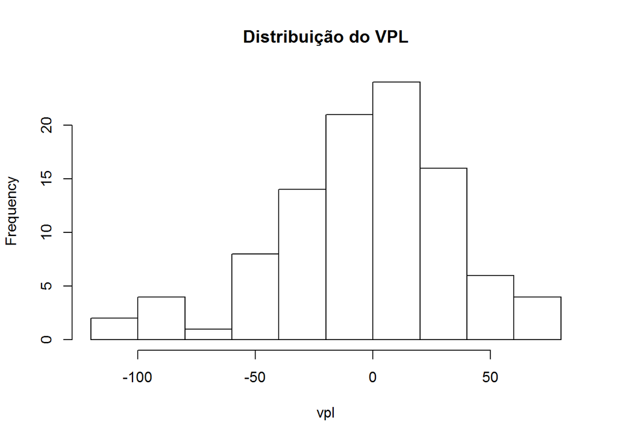

```r
# Ajustando o Gráfico para 3 imagens:
# par(mfrow=c(1,3))
# Vendo a Distribuição do VPL
hist(vpl,main="Distribuição do VPL")
```

CBR…

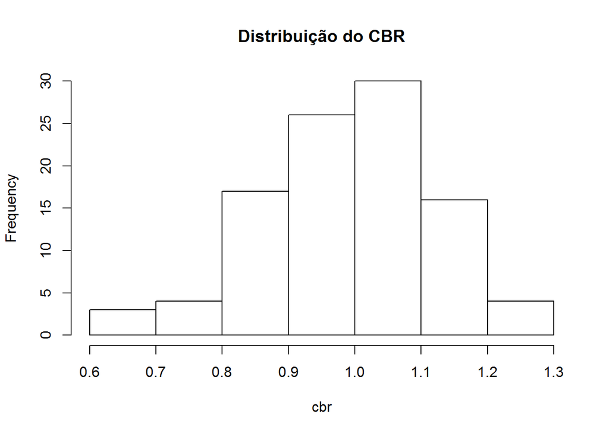

```r
# Vendo a Distribuição do CBR
hist(cbr,main="Distribuição do CBR")
```

ROI…

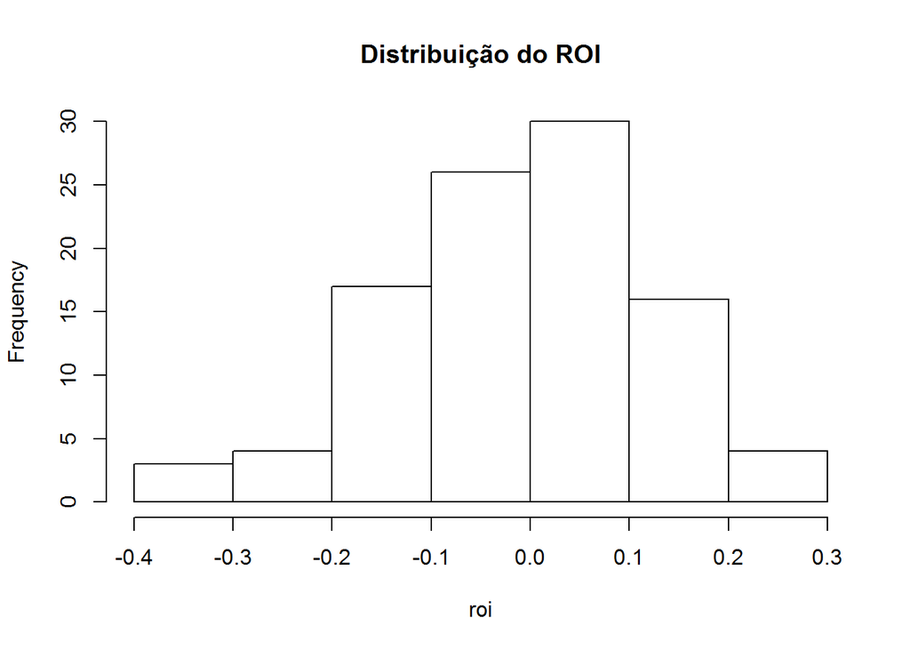

```r
# Vendo a Distribuição do CBR
hist(roi,main="Distribuição do ROI")
```

Assumindo que estes dados tem uma distribuição normal, vamos estimar agora os índices.

```r
# Ajustando o CBA para uma distribuição normal
cbr_fit = fitdist(cbr,"norm")
roi_fit = fitdist(roi,"norm")
vpl_fit = fitdist(vpl,"norm")
```

Vamos estimar o CBR!

```r
# Estimando o CBR

cbr_medio = as.numeric(cbr_fit$estimate[["mean"]])
cbr_medio = round(cbr_medio, digits=2)

cat("Para cada 1 real investido em SST, retornam em média ", cbr_medio, " Reais.")
```

```
## Para cada 1 real investido em SST, retornam em média  0.99  Reais.
```

Podemos calcular um intervalo de confiança!

```r
confint(cbr_fit)
```

```
##          2.5 %   97.5 %
## mean 0.9642116 1.013237
## sd   0.1077380 0.142394
```

Vamos estimar o ROI!

```r
# Estimando o ROI
roi_medio = as.numeric(roi_fit$estimate[["mean"]])*100
roi_medio = round(roi_medio,digits = 2)

cat("O retorno sobre investimento esperado é de ", roi_medio, " %.")
```

```
## O retorno sobre investimento esperado é de  -1.13  %.
```

Podemos calcular um intervalo de confiança!

```r
confint(roi_fit)
```

```
##            2.5 %     97.5 %
## mean -0.03578844 0.01323653
## sd    0.10773804 0.14239396
```

Vamos estimar o VPL!

```r
# Informando o VPL
vpl_medio = as.numeric(vpl_fit$estimate[["mean"]])
vpl_medio = round(vpl_medio,digits = 2)

cat("O Valor Presente Líquido do Investimento esperado é ", vpl_medio, " Reais.")
```

```
## O Valor Presente Líquido do Investimento esperado é  -4.3  Reais.
```

Podemos calcular um intervalo de confiança!

```r
confint(vpl_fit)
```

```
##         2.5 %    97.5 %
## mean -11.7338  3.143422
## sd    32.6929 43.212687
```

Feito, temos um protótipio de análise probabilística do CBA!